# 04 · 回归稳定性、过拟合与 PCA

## 目标 · Goal

理解三个不同问题：系数能否稳定估计、预测能否泛化、低维表示保留了多少样本方差。 需要的准备：最小二乘、向量投影、样本协方差；可先完成第 01 本。

## 准备 · Setup

先在网页预测结果、拖动参数，再回到这里复算。代码只使用合成数据，不读取学习记录。 所有随机数使用 NumPy PCG64；固定种子可重现本 Notebook，**不意味着与网页的随机样本逐项一致**。 数学定义、参数和边界与网页一致。独立核验脚本另外直接读取网页原始样本，再用 NumPy/SciPy 复算。

运行环境：Python 3.12+，依赖见 `../requirements.txt`。从顶部顺序运行全部单元格；图表标签用英语，讲解用中文。

**Python · cell 3**

```
from pathlib import Path
import sys
candidates = [Path.cwd(), Path.cwd().parent, Path.cwd() / "python"]
source_dir = next((p for p in candidates if (p / "lab_reference.py").is_file()), None)
if source_dir is None:
    raise FileNotFoundError("从 python/notebooks 或 python 目录运行此 Notebook")
sys.path.insert(0, str(source_dir))
import numpy as np
from scipy.stats import norm, beta as beta_distribution
from numpy.polynomial.legendre import legvander
import matplotlib.pyplot as plt
import lab_reference as lab
%matplotlib inline
plt.rcParams.update({"figure.figsize": (9, 4.4), "figure.dpi": 125,
                     "font.size": 11, "axes.spines.top": False,
                     "axes.spines.right": False, "axes.grid": True,
                     "grid.alpha": .18, "axes.axisbelow": True})
BLUE, ORANGE, OLIVE, INK = "#24658c", "#bc6327", "#69743a", "#24323c"
SEED = 42
print("NumPy", np.__version__, "· seed", SEED, "· independent PCG64 draws")
```

```
NumPy 2.5.3 · seed 42 · independent PCG64 draws
```

## 实验 9 · 相关预测变量与 Ridge

预测变量先用训练样本均值与样本标准差标准化。目标函数为 $\|y-\beta_0\mathbf1-X\beta\|^2+\lambda\|\beta\|^2$，**截距不惩罚**，损失没有除以样本量。 两个标准化预测变量时，经验 VIF 为 $1/(1-r^2)$；这里 $r$ 是实现样本的相关系数，未必恰好等于生成参数 $\rho$。

**Python · cell 5**

```
rho=.98
penalties=[0,.1,1,10]
fits=[lab.compute("regression",rho=rho,**{"lambda":penalty},seed=SEED) for penalty in penalties]
fig,axes=plt.subplots(1,2,figsize=(11,4.3),layout="constrained")
for i,color,style in [(0,BLUE,"-o"),(1,ORANGE,"--s")]:
    axes[0].plot(penalties,[r["beta"][i] for r in fits],style,color=color,label=f"beta {i+1}")
axes[0].axhline(1,color=INK,linestyle=":",label="True coefficients")
axes[0].set(xlabel="Ridge lambda (sum-loss)",ylabel="Estimated coefficient",title="Coefficients under collinearity"); axes[0].legend()
r=fits[-1]
axes[1].scatter(r["predictions"],r["residuals"],facecolors="none",edgecolors=BLUE,s=32)
axes[1].axhline(0,color=INK,linestyle=":")
axes[1].set(xlabel="Fitted response",ylabel="Residual",title="Residuals at lambda = 10")
plt.show()
print(f"Empirical r={r['sampleCorrelation']:.6f}; VIF={r['vif']:.4f}; design condition={r['conditionNumber']:.4f}")
assert abs(np.mean(r["residuals"]))<1e-12
assert np.allclose(fits[0]["beta"],fits[0]["olsBeta"])
print("OLS coefficients:",np.round(fits[0]["beta"],4),"; Ridge coefficients:",np.round(r["beta"],4))
```

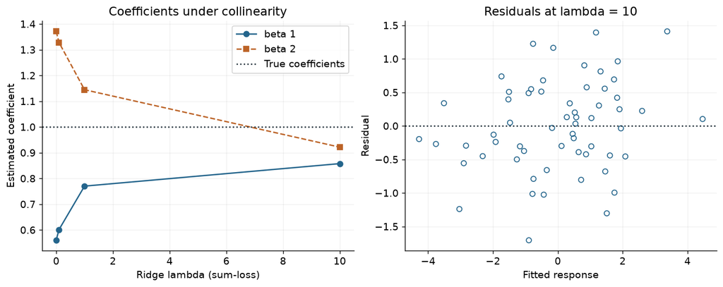

```
Empirical r=0.985480; VIF=34.6871; design condition=11.6936
OLS coefficients: [0.5601 1.3713] ; Ridge coefficients: [0.8577 0.9217]
```

Ridge 用偏差换稳定性，但不保证每个系数都单调向零，也不保证某一次数据上的预测更好。

**自己试：** 将 `rho` 从 0.98 改为 0，比较经验 VIF；再换种子比较系数波动。

## 实验 10 · 多项式拟合与验证误差

真实函数为 $\sin(\pi x)$，训练和验证样本独立生成。使用 Legendre 基，截距不惩罚；独立实现用增广设计矩阵的 SVD 最小二乘求解。 训练误差衡量已见数据上的拟合，验证误差衡量这一固定验证集上的预测。反复看验证集选择模型后，需要另留测试集评价最终性能。

**Python · cell 8**

```
degrees=[1,3,5,9,15]
fits=[lab.compute("overfit",degree=d,n=20,noise=.25,**{"lambda":.001},seed=SEED) for d in degrees]
xx=np.linspace(-1,1,400)
fig,axes=plt.subplots(1,2,figsize=(11,4.4),layout="constrained")
axes[0].plot(xx,np.sin(np.pi*xx),color=INK,label="True sin(pi x)")
axes[0].scatter(fits[0]["train"]["x"],fits[0]["train"]["y"],s=28,facecolors="none",edgecolors=INK,label="Training n=20")
for degree,color,style in [(1,ORANGE,":"),(5,BLUE,"--"),(15,OLIVE,"-")]:
    fit=fits[degrees.index(degree)]
    axes[0].plot(xx,legvander(xx,degree)@fit["coefficients"],style,color=color,label=f"Degree {degree}")
axes[0].set(xlabel="x",ylabel="Response",title="One fixed train / validation split"); axes[0].legend(fontsize=9)
axes[1].plot(degrees,[r["trainMSE"] for r in fits],"o-",color=BLUE,label="Training MSE")
axes[1].plot(degrees,[r["validationMSE"] for r in fits],"s--",color=ORANGE,label="Validation MSE (n=300)")
axes[1].set(xlabel="Polynomial degree",ylabel="Mean squared error",title="Observed errors; no enforced U shape"); axes[1].legend(fontsize=9)
plt.show()
for d,r in zip(degrees,fits): print(f"degree {d:2d}: train={r['trainMSE']:.5f}, validation={r['validationMSE']:.5f}")
assert all(np.array_equal(fits[0]["train"]["y"],r["train"]["y"]) for r in fits)
assert np.allclose(fits[2]["design"],legvander(fits[2]["train"]["x"],5))
```

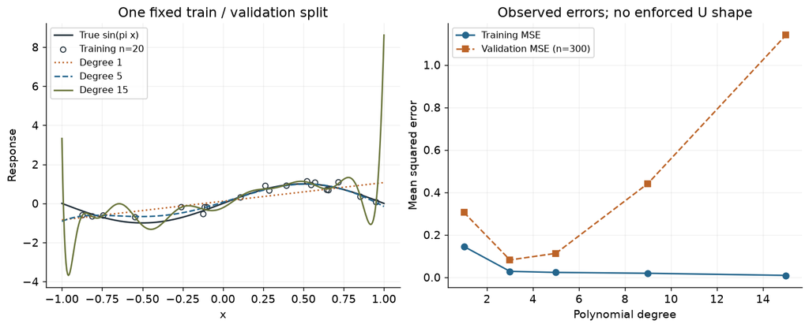

```
degree  1: train=0.14501, validation=0.30538
degree  3: train=0.02792, validation=0.08158
degree  5: train=0.02282, validation=0.11270
degree  9: train=0.01882, validation=0.44141
degree 15: train=0.00880, validation=1.13990
```

改变次数时保持数据不变，才能把可见变化归因于模型。误差曲线是这份数据的观测结果，不要求每一次都出现教科书式 U 形。

**自己试：** 用 `n=10, degree=15, lambda=0` 创建欠定问题。NumPy 会返回最小范数解；拟合存在不等于系数唯一，也不等于网页一定采用同样的非唯一解约定。

## 实验 11 · PCA 与重建误差

对中心化后的数据做样本协方差分解；可选标准化后得到相关矩阵 PCA。 特征向量的正负号任意；重复特征值对应的方向不唯一。比较实现时，应比较特征子空间、重建和解释方差，不能只比较向量逐项符号。 这里重建误差定义为每个观测的**两个坐标平方误差之和**再取平均。

**Python · cell 11**

```
fig,axes=plt.subplots(1,2,figsize=(11,4.5),layout="constrained")
for ax,standardize in zip(axes,[0,1]):
    r=lab.compute("pca",angle=35,ratio=4,scale=2,n=120,standardize=standardize,seed=SEED)
    observed=r["processed"]; rebuilt=r["reconstruction"]
    ax.scatter(*observed.T,s=14,color=BLUE,alpha=.6,label="Processed observations")
    ax.scatter(*rebuilt.T,s=15,facecolors="none",edgecolors=ORANGE,label="Rank-1 reconstruction")
    for p,q in zip(observed[:20],rebuilt[:20]): ax.plot([p[0],q[0]],[p[1],q[1]],color="#999",linewidth=.65)
    ax.set_aspect("equal",adjustable="datalim")
    ax.set(xlabel="Processed coordinate 1",ylabel="Processed coordinate 2",
           title=("Correlation" if standardize else "Covariance")+f" PCA: {r['explainedRatio']:.1%}")
    ax.legend(fontsize=9)
    expected=r["eigenvalues"][1]*(len(observed)-1)/len(observed)
    assert np.isclose(r["reconstructionMSE"],expected)
    print(("Standardized" if standardize else "Centered"),"eigenvalues",np.round(r["eigenvalues"],5),"; reconstruction error",round(r["reconstructionMSE"],5))
plt.show()
```

```
Centered eigenvalues [30.88741  1.3034 ] ; reconstruction error 1.29253
Standardized eigenvalues [1.89874 0.10126] ; reconstruction error 0.10042
```

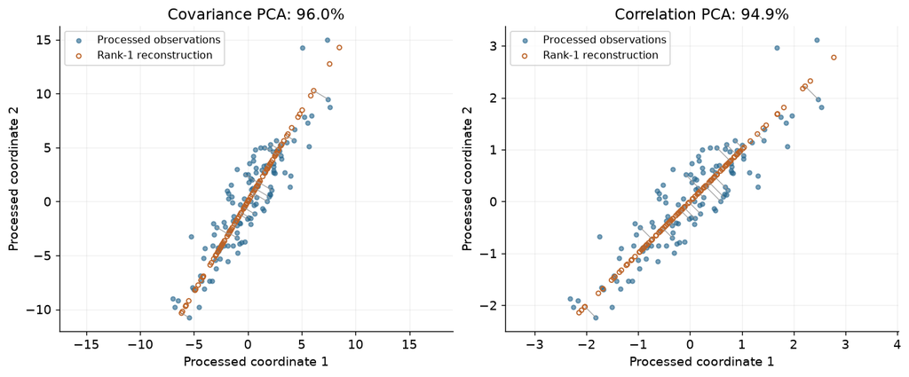

由于协方差使用分母 $n-1$，每观测重建平方误差等于 $(n-1)\lambda_2/n$。标准化改变了距离的含义，两个面板误差的单位也不同，不能直接作为优劣排名。

**自己试：** 固定生成样本，改变第二坐标的 `scale`。协方差 PCA 会受单位缩放影响；标准化后的相关矩阵 PCA 对正的逐坐标缩放不变。

## 检查 · Checks

核对截距导致残差均值为零、零惩罚 Ridge 等于 OLS、改变多项式次数保留同一训练样本、Legendre 设计矩阵和 PCA 特征值—重建误差恒等式。

## 接下来 · Next steps

选择一个你无法口头解释的参数，先在网页试验，再修改 Notebook、保留一个结果和一句解释。实验记录可单独保存；本文件不记录个人掌握程度。

来源：[NumPy 最小二乘及最小范数约定](https://numpy.org/doc/stable/reference/generated/numpy.linalg.lstsq.html)、[NumPy 对称矩阵特征分解](https://numpy.org/doc/stable/reference/generated/numpy.linalg.eigh.html)、[NumPy Legendre 设计矩阵](https://numpy.org/doc/stable/reference/generated/numpy.polynomial.legendre.legvander.html)、[scikit-learn Ridge 目标](https://scikit-learn.org/stable/modules/generated/sklearn.linear_model.Ridge.html)。